# Practical Machine Learning

Dr. Chem. Eng. Nikolaos Fotopoulos

Sunday, April 26, 2015

# MachineLearn

### Course Project submission for John Hopkins Univ. Practical Machine Learning , Coursera course.

#### Background

Using devices such as Jawbone Up, Nike FuelBand, and Fitbit it is now possible to collect a large amount of data about personal activity relatively inexpensively. These type of devices are part of the quantified self movement – a group of enthusiasts who take measurements about themselves regularly to improve their health, to find patterns in their behavior, or because they are tech geeks. One thing that people regularly do is quantify how much of a particular activity they do, but they rarely quantify how well they do it.

### Data

The data for this project come from this source: http://groupware.les.inf.puc-rio.br/har.

### Citation

Velloso, E.; Bulling, A.; Gellersen, H.; Ugulino, W.; Fuks, H. Qualitative Activity Recognition of Weight Lifting Exercises. Proceedings of 4th International Conference in Cooperation with SIGCHI (Augmented Human ’13) . Stuttgart, Germany: ACM SIGCHI, 2013.

### Goal

The goal of the project is to predict the manner in which they did the exercise. This is the “classe” variable in the training set. We use any of the other variables to predict with and we should create a report describing how we built our model, how we used *cross validation*, what we think *the expected out of sample error* is, and why we made the choices we did. We will also use our prediction model to *predict* 20 different test cases.

*make sure time is in correct format*

```r
Sys.setlocale("LC_TIME", "English")
```

```
## [1] "English_United States.1252"
```

#### Data Loading

```r
trainURL<-"https://d396qusza40orc.cloudfront.net/predmachlearn/pml-training.csv"
testURL<-"https://d396qusza40orc.cloudfront.net/predmachlearn/pml-testing.csv"
```

*however the download is not working easily in all places, so we load from a local file* *Also from preemptive examination of the raw data we know that NA in data is coded as NA or #DIV/0! or just blank. So, we will rectify the NAs by using the na.strings option in read.csv function*

```r
training <- read.csv(file="C:/data/pml-training.csv", header=TRUE,sep=',',na.strings=c("NA","#DIV/0!",""))
testing <- read.csv(file="C:/data/pml-testing.csv", header=TRUE,sep =',',na.strings=c("NA","#DIV/0!",""))
```

#### Examine the Data

*dimensions…*

```r
dim(training)
```

```
## [1] 19622   160
```

*We scrutinize structure. We check fot NA tokens, sparce, near zero variance and dummy variables (too big we ommit displaying it due to 2000 words limit)*

```r
str(training)
sapply(training,class)
summary(training)
```

*we observe there are a lot of dummy variables zero variance variables and different tokens for NA’s, so we need to discard them and concentrate on numerical variables*

#### Data cleaning

```r
NA_ratio_train<-apply(training,2,function(x) {sum(is.na(x))/dim(training)[1]})
```

*We use this ratio to reject any column that is filled with more than 30% NA’S*

```r
training<-training[,which(NA_ratio_train < 0.30)]
testing<-testing[,which(NA_ratio_train < 0.30)]
```

*we verify that we have the same number of variables selected*

```r
dim(training)[2]
```

```
## [1] 60
```

```r
dim(testing)[2]
```

```
## [1] 60
```

*we eliminate some remaining irrrelevant columns by hand*

```r
training<-training[,-(1:7)]
testing<-testing[,-(1:7)]
```

*Inspect the remaining variables (results = ‘hide’) to save space…*

```r
summary(training)
```

#### Data Preprocessing

```r
#training$classe <- as.factor(training$classe)
#testing$classe <- as.factor(testing$classe)
numvars <- which(lapply(training, class) %in% "numeric")
numvars
```

```
##  [1]  1  2  3  5  6  7 14 15 16 18 19 20 27 28 29 31 32 33 39 40 41 42 44
## [24] 45 46 51 52
```

```r
library(caret)
varstoremove <- findCorrelation(cor(training[,numvars]), cutoff=0.7)
training<-training[,-varstoremove]
testing<-testing[,-varstoremove]
```

#### Model building

*dividing the trainset in train and test part*

```r
set.seed(263)
inTrain = createDataPartition(training$classe, p = 0.75, list=FALSE)
trainme = training[inTrain,]
testme = training[-inTrain,]
```

*since its a classification problem we opt for random forests 10-fold cross validation in 3 repetitions*

```r
tctrl<- trainControl(method="repeatedcv", number=10,  repeats=3)
model <- train(classe ~., method="rf", data=trainme, trControl=tctrl, number=5, ntree=501)
model
```

```
## Random Forest
##
## 14718 samples
##    47 predictor
##     5 classes: 'A', 'B', 'C', 'D', 'E'
##
## No pre-processing
## Resampling: Cross-Validated (10 fold, repeated 3 times)
##
## Summary of sample sizes: 13247, 13246, 13246, 13244, 13246, 13247, ...
##
## Resampling results across tuning parameters:
##
##   mtry  Accuracy   Kappa      Accuracy SD  Kappa SD
##    2    0.9913709  0.9890835  0.002128359  0.002693390
##   24    0.9903298  0.9877674  0.002600172  0.003289090
##   47    0.9807498  0.9756493  0.003416869  0.004321974
##
## Accuracy was used to select the optimal model using  the largest value.
## The final value used for the model was mtry = 2.
```

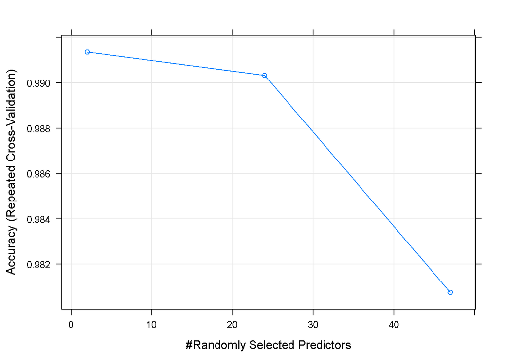

```r
plot(model)
```

*re;ative importance of predictors*

```r
importance =    varImp(model,   scale=FALSE)
importance
```

```
## rf variable importance
##
##   only 20 most important variables shown (out of 47)
##
##                   Overall
## roll_belt           578.9
## magnet_dumbbell_z   462.7
## pitch_belt          417.5
## magnet_dumbbell_y   412.5
## pitch_forearm       405.6
## roll_forearm        387.8
## magnet_dumbbell_x   370.9
## accel_belt_z        336.5
## accel_dumbbell_y    326.0
## magnet_belt_z       320.9
## roll_dumbbell       315.6
## magnet_belt_y       315.5
## accel_dumbbell_z    291.8
## roll_arm            286.1
## accel_arm_x         278.3
## accel_forearm_x     271.9
## gyros_belt_z        253.9
## accel_dumbbell_x    247.4
## magnet_forearm_z    244.1
## gyros_dumbbell_y    242.6
```

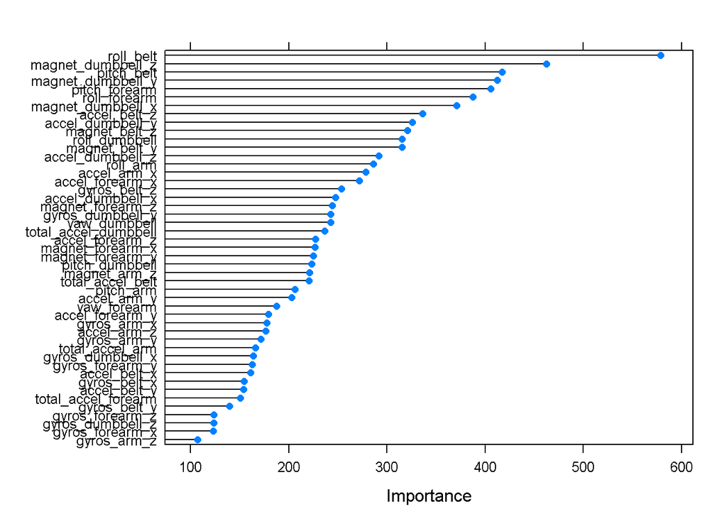

```r
plot(importance)
```

*performance of the model*

```r
predictions <- predict(model, testme)
confusionMatrix(testme$classe, predictions)
```

```
## Confusion Matrix and Statistics
##
##           Reference
## Prediction    A    B    C    D    E
##          A 1395    0    0    0    0
##          B    3  944    2    0    0
##          C    0    4  849    2    0
##          D    0    0   22  782    0
##          E    0    0    0    4  897
##
## Overall Statistics
##
##                Accuracy : 0.9925
##                  95% CI : (0.9896, 0.9947)
##     No Information Rate : 0.2851
##     P-Value [Acc > NIR] : < 2.2e-16
##
##                   Kappa : 0.9905
##  Mcnemar's Test P-Value : NA
##
## Statistics by Class:
##
##                      Class: A Class: B Class: C Class: D Class: E
## Sensitivity            0.9979   0.9958   0.9725   0.9924   1.0000
## Specificity            1.0000   0.9987   0.9985   0.9947   0.9990
## Pos Pred Value         1.0000   0.9947   0.9930   0.9726   0.9956
## Neg Pred Value         0.9991   0.9990   0.9941   0.9985   1.0000
## Prevalence             0.2851   0.1933   0.1780   0.1607   0.1829
## Detection Rate         0.2845   0.1925   0.1731   0.1595   0.1829
## Detection Prevalence   0.2845   0.1935   0.1743   0.1639   0.1837
## Balanced Accuracy      0.9989   0.9973   0.9855   0.9935   0.9995
```

```r
table(predictions,testme$classe)
```

```
##
## predictions    A    B    C    D    E
##           A 1395    3    0    0    0
##           B    0  944    4    0    0
##           C    0    2  849   22    0
##           D    0    0    2  782    4
##           E    0    0    0    0  897
```

*we apply the model to the original testing data set*

```r
results <- predict(model, testing)
results
```

```
##  [1] B A B A A E D B A A B C B A E E A B B B
## Levels: A B C D E
```

*may the R be with you…*